# Part II - (Prosper's Loan Data Exploration)

## by (Azukaego Uzoagozie Umeononigwe)

## Investigation Overview

> From the exploration, it is evident that a number of factors have impact on the estimated return and status of the loan. Negative returns were observed for loans taken for 36 months but that was not the case for 12 or 60 months loans. This was evident during the exploration done between estimated return and term.

> In addition the highest estimated returns were also observed for loans within the 36 months payback period

> Also a direct relationship was obeserved between borrower rate and borrower apr. borrower apr increased simultaneously as borrower rate increased

## Dataset Overview

> The dataset discusses loan data gotten from Propser. A total of 113,937 loans with 81 features for each loan was provided for the data exploration. These features are not limited to the actual loan that was taken, the estimated return, the interest rate, the loan duration, etc

## 1. Distribution of Loan status

> The current loan status has the highest frequency and the least is the cancelled loans

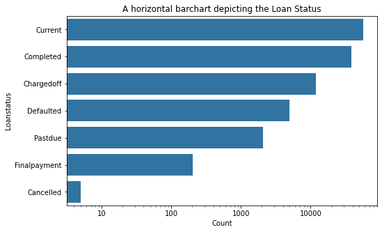

## 2. Distribution of Estimated Return

> The estimated return is skewed to the left. Axis transformation was done in other to have a clear picture of the distribution

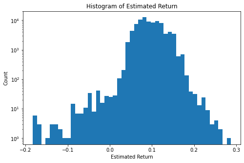

## 3. Distribution of Loan Status across Income Range

> There were more current loans across all income ranges except 1-24.99k which has a higher loan completion rate

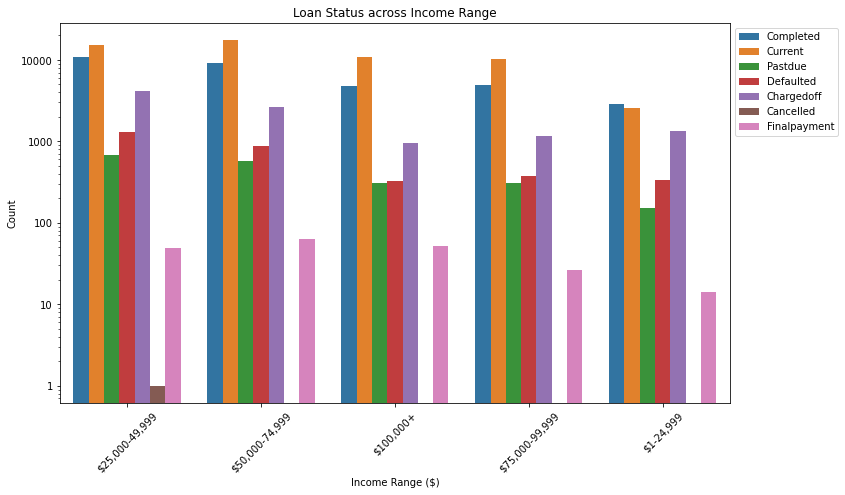

## 4. Correlation of Estimated Return and Loan Original Amount by Term

> The main focus is the impact of the term of the loan on Estimated return but with a possible assessment of the impact of the loan original amount.

> A scatter plot was used to generate the insight

> It is evident that negative estimated returns occured for loans taken for 36 months and particularly loans of smaller amount. Loans that were taken for 12 or 60 months all experienced positive returns which is a good insight for investment.

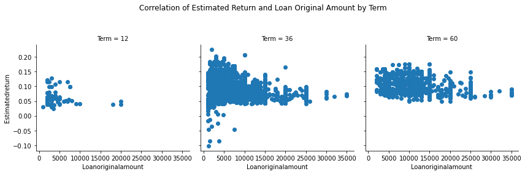

## SUMMARY

#### Findings

1. Active or current loans had the highest frequency
2. Estimated return skewed to the left as well as showing negative returns
3. There were more current loans across all income ranges except 1-24.99k where completed loans has the highest frequency
4. Negative estimated returns occured for loans taken for 36 months and particularly loans of smaller amount. Loans that were taken for 12 or 60 months all experienced positive returns

#### Limitations

1. The loan dataset has a total of 81 variables but only 12 were utilized which limited the amount of information we could use
2. Detailed data cleaning could not be done because the number of features. For example, dropping unwanted features may affect the variables of interes